# Differential gene expression new groups

Amy Cross

2024-01-19

### Libraries

### Import data

### Volcano plot functions

### Co-infection (PT3)_immune high (A) vs immune low (B)

A: 30-80% Immune and 80-100% HBV B: 2-10% Immune and 80-100% HBV

```
## [1] "Number of FDR signficant genes over 1.5 fold change: 611"
```

```
## [1] "Number of unadjusted signficant genes over 1.5 fold change: 645"
```

If res requires the condition (e.g. conditionB) then it will be the positive log2FC. In this case, it is conditionB.

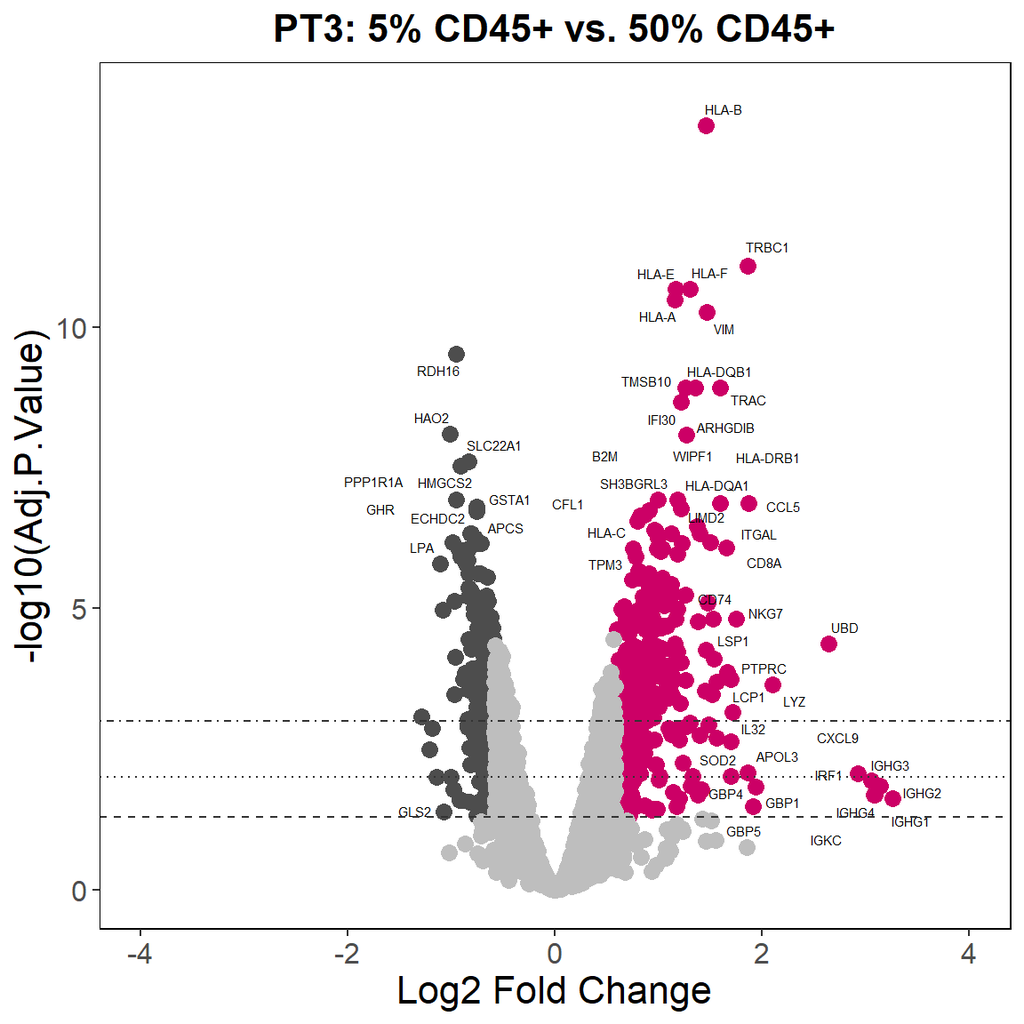

GO.BP pathways analysis

If res requires the condition (e.g. conditionB) then it will be the positive log2FC. In this case, it is conditionB. A: 30-80% Immune and 80-100% HBV B: 2-10% Immune and 80-100% HBV

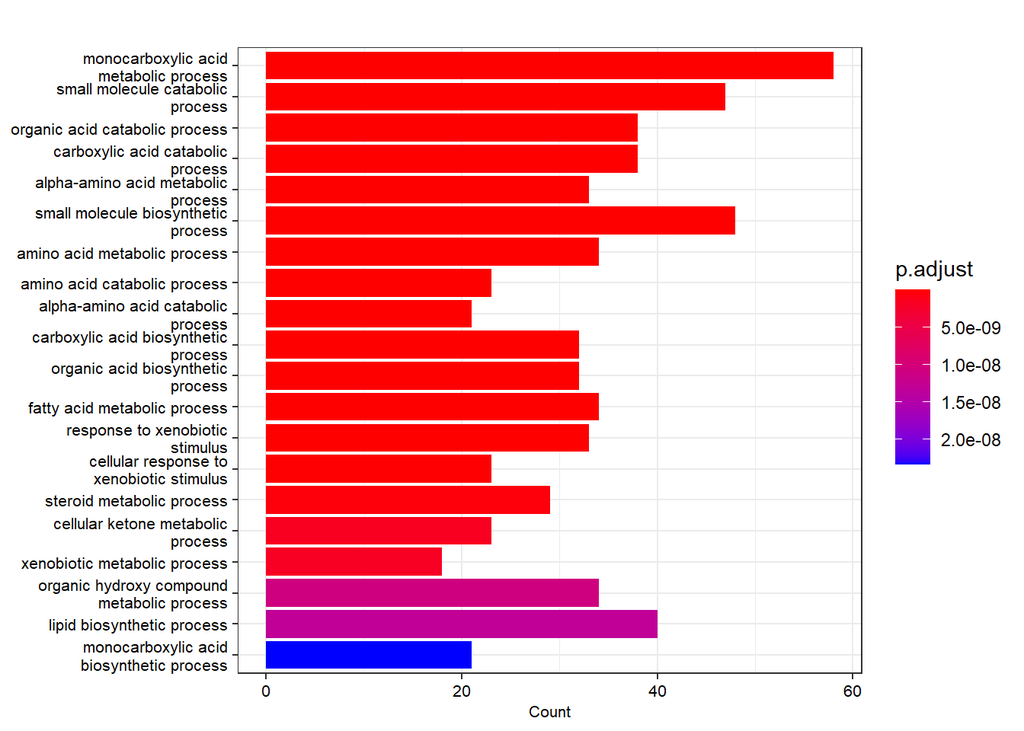

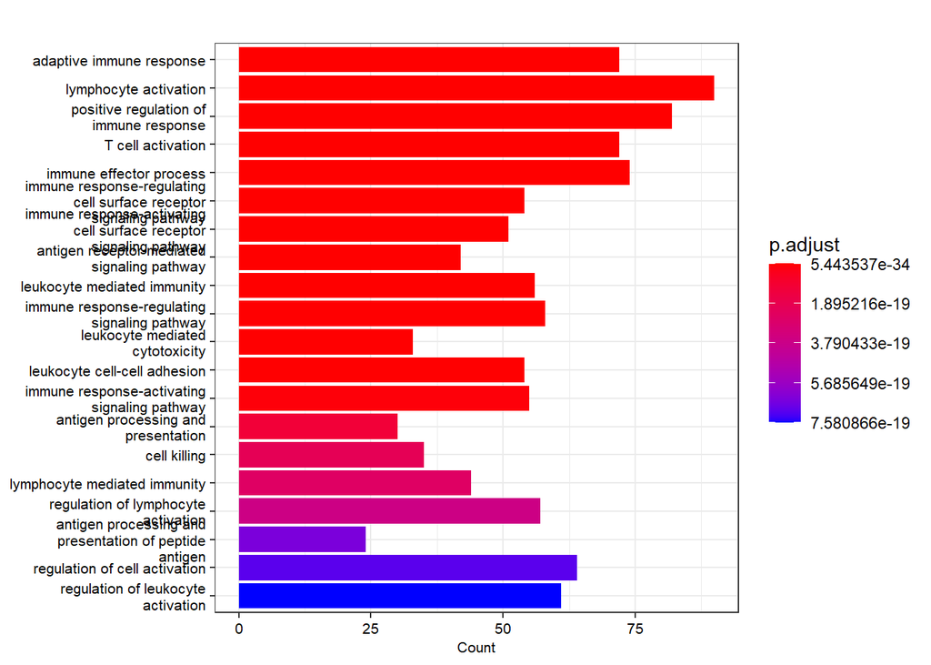

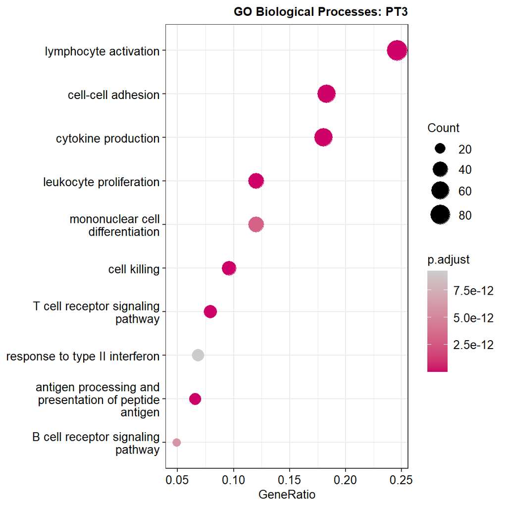

### Low fibrosis (PT1)_HBV high (D) vs HBV low (E)

C: 2-10% Immune and 80-100% HBV D: 0 Immune and 80-100% HBV E: 0 Immune and 0% HBV

```
## [1] "Number of FDR signficant genes over 1.5 fold change: 0"
```

```
## [1] "Number of unadjusted signficant genes over 1.5 fold change: 50"
```

If res requires the condition then it will be the positive log2FC. In this case, it is conditionE. D: 0 Immune and 80-100% HBV E: 0 Immune and 0% HBV

There was no GO pathways associated with high HBV.

### Low fibrosis (PT1)_Immune high (C) vs Immune low (D)

C: 2-10% Immune and 80-100% HBV D: 0 Immune and 80-100% HBV E: 0 Immune and 0% HBV

```
## [1] "Number of FDR signficant genes over 1.5 fold change: 0"
```

```
## [1] "Number of unadjusted signficant genes over 1.5 fold change: 40"
```

If res requires the condition then it will be the positive log2FC. In this case, it is conditionD. D: 0 Immune and 80-100% HBV C: 2-10% Immune and 80-100% HBV

There are no GO pathways associated with low immune ROI.

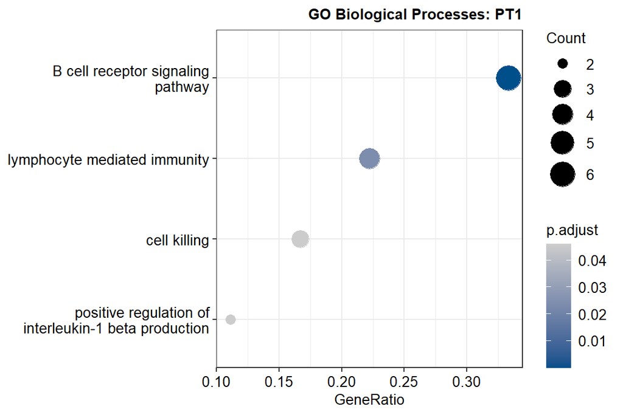

### High fibrosis (PT2)_HBV high (H) vs HBV low (F)

F: 0 Immune and 0-1% HBV H: 0 Immune and 20% HBV I: 40% Immune and 40% HBV

```
## [1] "Number of FDR signficant genes over 1.5 fold change: 0"
```

```
## [1] "Number of unadjusted signficant genes over 1.5 fold change: 370"
```

If res requires the condition then it will be the positive log2FC. In this case, it is conditionH. F: 0 Immune and 0-1% HBV H: 0 Immune and 20% HBV

There are no GO Pathways for the HBV low ROIs.

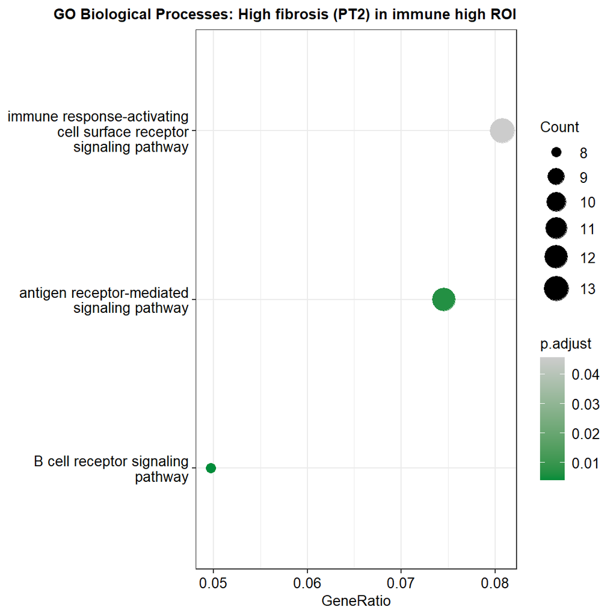

### High fibrosis (PT2)_Immune high (I) vs Immune low (H)

F: 0 Immune and 0-1% HBV H: 0 Immune and 20% HBV I: 40% Immune and 40% HBV

```
## [1] "Number of FDR signficant genes over 1.5 fold change: 868"
```

```
## [1] "Number of unadjusted signficant genes over 1.5 fold change: 1813"
```

If res requires the condition then it will be the positive log2FC. In this case, it is conditionI. I: 40% Immune and 40% HBV H: 0 Immune and 20% HBV

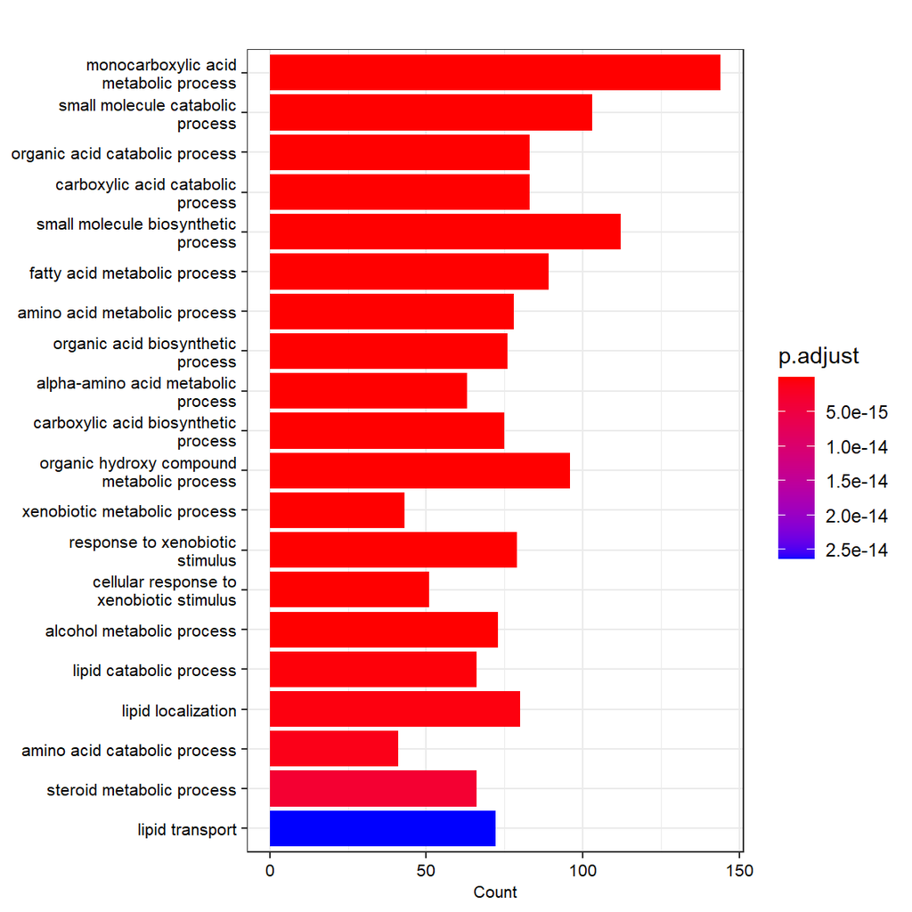

GO.BP pathways analysis

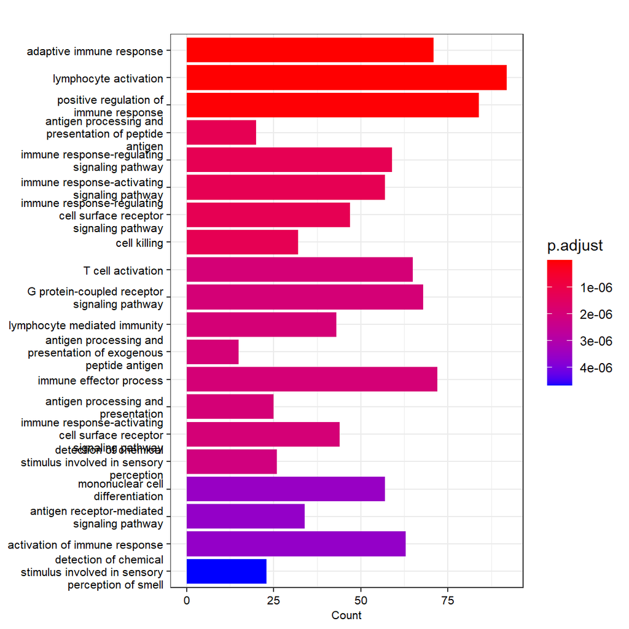

GO.BP pathways analysis

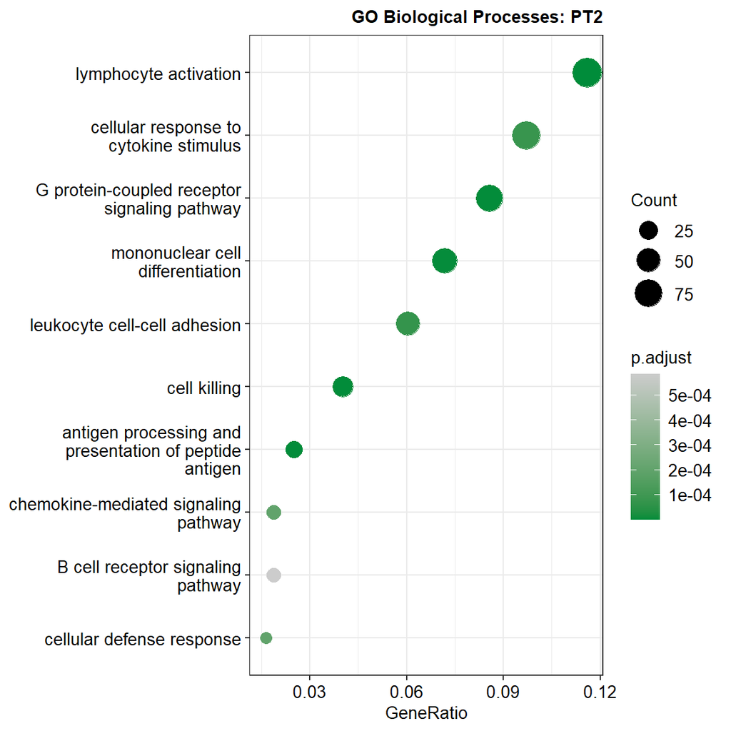

### High fibrosis (PT2)_HBV high/Immune high (I) vs HBV low/Immune low (F)

F: 0 Immune and 0-1% HBV H: 0 Immune and 20% HBV I: 40% Immune and 40% HBV

```
## [1] "Number of FDR signficant genes over 1.5 fold change: 729"
```

```
## [1] "Number of unadjusted signficant genes over 1.5 fold change: 1835"
```

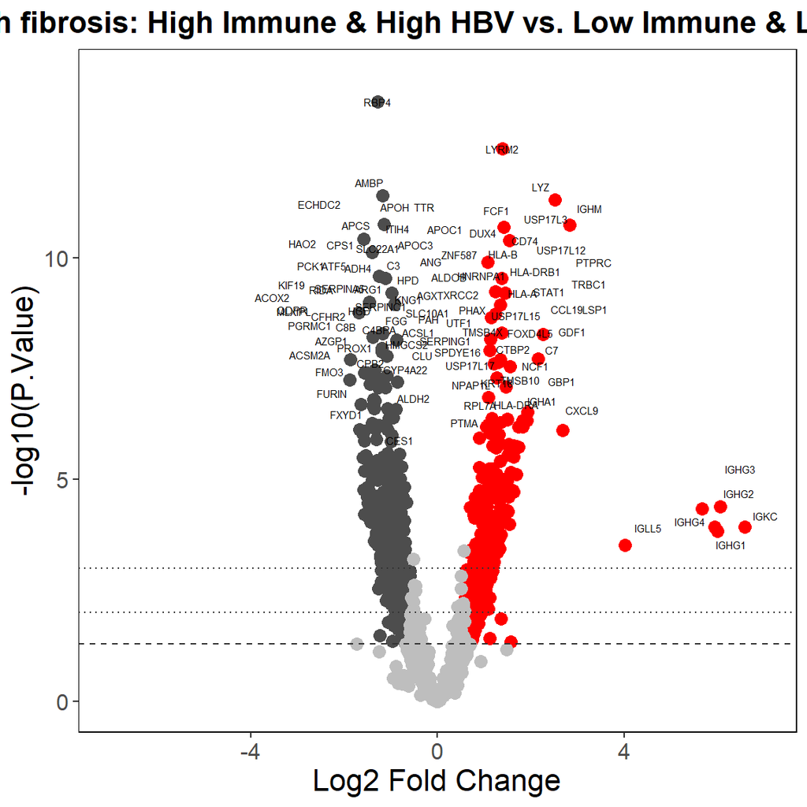

GO.BP pathways analysis

If res requires the condition then it will be the positive log2FC. In this case, it is conditionI.

F: 0 Immune and 0-1% HBV I: 40% Immune and 40% HBV

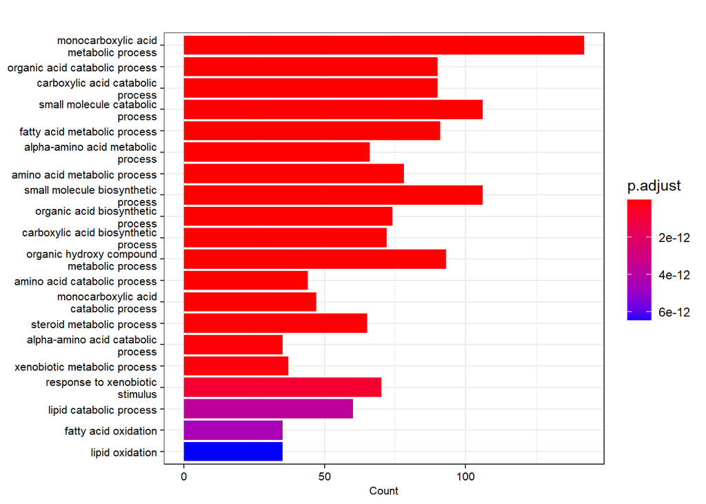

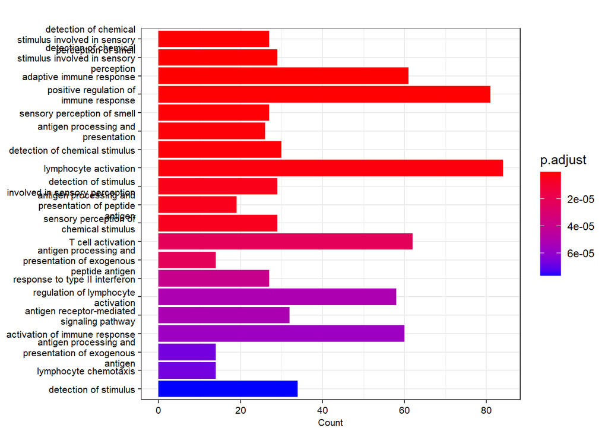

## The end